# PHYS 210 Day 04 - Sep 15, 2025

Agenda:

1. Announcements
2. Reading recap (Q&A and polling questions)
3. Groupwork

## Preclass preparation as part of the learning cycle

Lots of productive quesitons being asked via the Preclass assignment submissions. Don't forget that the complete set of answers to your questions is available on Canvas.

The preclass preparations assignments are meant to give you some initial exposure to terminology and concepts. They set you up to benefit from the additional practice that comes from the collaborative group worksheets and subsequent homework. The preparation assignments are just step 1 in a multi-step learning process. Having initial, but not complete understanding of the concepts by the end of step 1 is more than good enough.

## Reading recap, Q&A and polling questions

**Arrays**

Terminology:

- rank, row, column, length, axis

Array attributes:

- ndim, shape, size, dtype, itemsize

Methods:

- So many!

```python
# Array Creation:
import numpy as np
a = np.array([1, 2, 3])
b = np.array([[1, 2, 3, 4], [5, 6, 7, 8], [9, 10, 11, 12]])
c = np.zeros((5, 3))
print(a)
```

```python
# Array slicing: a[1], b[0, 2], b[:, 2]
b[0:2, 1:3]
```

```python
# Array methods: eg. a.sum(), a.mean(), a.std()
a.sum()
```

```python
# Array math: +, -, /, *
# - Different types of products: a*a, np.dot(a,a)
np.dot(a,a)
```

**Q:** I don't understand the why the answer to Self-assessment Q1

What will the following code print?

```python
import numpy as np
a = np.array([[1, 2, 3], [4, 5, 6], [7, 8, 9]])
print(np.ndim(a))
print("")
print(a)
```

We can rearrange the presentation to see that it is a 2D array with shape (3,3), meaning 3 rows and 3 columns

```
[[1, 2, 3],
 [4, 5, 6],
 [7, 8, 9]]
```

Let's spend a bit of time reviewing dimensions and array indexing using a helpful visual resource: https://www.pythoninformer.com/python-libraries/numpy/index-and-slice/

**Polling Q1:** What will the following code print?

```python
import numpy as np
a = np.array( [ [ [1, 2], [4,3]],[ [8,1], [8,3] ],
               [ [5,7],[0,8] ],[ [2,7],[6,5] ] ] )
print(np.ndim(a))
#print(a)
```

A) 16  
B) 8  
C) 4  
D) 3  
E) 2

**Q:** More about `np.zeros_like()`

```python
import numpy as np
A = np.array([[9, 1], [4, 2]])

print(np.size(A)) # size is total number of elements in array
C1 = np.zeros(np.size(A))
print(C1)
```

```python
print(np.shape(A)) # shape is the dimensions of the array
C2 = np.zeros(np.shape(A))
print(C2)
```

```python
C3 = np.zeros_like(A, dtype=float) # default is int, unline np.zeros
print(C3)
```

**Important note about dtype:** Once we've set the data type, NumPy will try to force any new values to the correct data type

```python
a = np.zeros(5, dtype=int)
```

```python
a[0] = 3
print(a)
```

```python
a[1] = 1.8
print(a)
```

```python
a[2] = "four"
print(a)
```

**Polling Q2:** What is printed by this array operation?

```python
import numpy as np
A = np.array([1,2,3])
B = np.array([4,5,6])
print(A*B)
```

A) 32  
B) `[5 7 18]`  
C) `[4 10 18]`  
D) `[12 10 4]`  
E) 15

**Polling Q3:** What will be the output of the following?

```python
import numpy as np
A = np.array([[1,2,3],[4,5,6],[7,8,9],[10,11,12]])
print( A[:, 1] )
```

A) `[1, 4, 7, 10]`  
B) `[1, 2, 3]`  
C) `[2, 5, 8, 11]`  
D) `[4, 5, 6]`

More on array indexing...

For the following 3D array `a3`, you would index a cell as `a3[i, j, k]`.

- The last index, $k$, selects the column,
- The second-last index, $j$, selects the row,
- The third-last (or first in this case) index, $i$, selects the plane/layer.

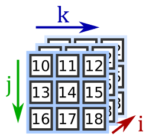

We could choose the middle row from each layer using either...

```
a3[:,1]
a3[:,1,:]
```

Where in either case

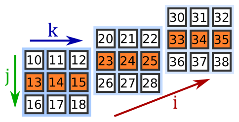

**Polling Q4:** What is the correct notation to take a slice containing the four elements shown in orange (13, 14, 16, 17)?

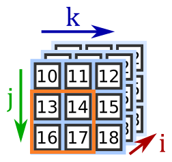

A) `a3[1, 2:4, 1: 3]`  
B) `a3[0, 1:3, 0:2]`  
C) `a3[0, 1:, :2]`  
D) `a3[0:2, 1:3, 0]`  
E) More than one of the above

### I don't understand the answer to self-assessment Q6 - Reference vs new object creation

What will be the output of the following?

```python
import numpy as np
x = np.array([1, 2]) # reference
y = x                # reference
z = x.copy()         # new object
r = 1*x              # new object
x[0] = 99
print("x:",x)
print("y:",y)
print("z:",z)
print("r:",r)
```

### Reference vs new object creation

Objects like lists or arrays can have multiple names that reference the same object

- `a = [1, 2, 3]`, `b = a`: `a` and `b` are different names for the same object
- If instead we’d said: `b = a * 1` then b and a would a new object
- After setting `b = a`, operations like: `a[0] = 5` change both a and b since they both reference the same object

You will usually want to use `b = a.copy()` instead of `a = b` when making copies of **mutable** containiners such as lists or arrays

# Group worksheet time

**Today:** Tables are grouped by similar level of programming experience

- **Larger groups (3-4):** Work on CoCalc or get somebody in the group to project to TV at the end of your table
- **Pairs (2):** Work **closely** with a partner, ideally on one device